# Metrics to measure uniqueness of gene sets identifed through ORA

Ally Hawkins

2026-03-11

This notebook looks at metrics to evaluate results from over-representation analysis:

- Number of observed gene sets
- Number of uniquely mapped gene sets
- Gene set specificity score

```r
library(ggplot2)

# Set default ggplot theme
theme_set(
  theme_bw()
)

set.seed(2026)
```

## Set Up

```r
# source functions for ora and metrics
# extract_top_genes(), run_ora(),
# prop_unique_mapped_genesets(), permute_unique_genesets()
source("utils/ora-helper-functions.R")
```

```r
# helper function for plotting permutation results
# plots background points with observed values in color on top as sina plot
plot_permutation_results <- function(background_df, pvalue_df, x_axis, y_axis){

  ggplot(background_df, aes(x = {{ x_axis }}, y = {{ y_axis }})) +
  ggforce::geom_sina(
    color = "gray",
    alpha = 0.1
  ) +
  geom_point(
    data = pvalue_df,
    aes(
      x = {{ x_axis }},
      y = {{ y_axis }},
      color = is_significant
    ),
    size  = 3,
    shape = 18  # diamond
  ) +
  scale_color_manual(values = c(`TRUE` = "red", `FALSE` = "blue")) +
  theme(
    axis.text.x = element_text(angle = 90)
  )

}
```

```r
# metaprograms results directory
results_dir <- here::here("ews-nf-out", "metaprograms")

# params we are looking at in this particular notebook
# use these to construct the file paths
n_metaprograms <- seq(5, 30, 1)

# directories with metaprogram results
# one directory per n_metaprogram
metaprogram_output_dirs <- file.path(
  results_dir,
  glue::glue("metaprograms-{n_metaprograms}_cnmf-5-10-15_filtered")
)

# path to files with each of the metrics
metrics_files <- file.path(metaprogram_output_dirs, "metaprograms-metrics.rds") |>
  purrr::set_names(sprintf("k_%02d", n_metaprograms))

# path to files for the actual objects
# we'll use these for re-running ORA
metaprogram_files <- file.path(metaprogram_output_dirs, "metaprograms.rds") |>
  purrr::set_names(sprintf("k_%02d", n_metaprograms))

# significance value so we don't accidentally mis type it
sig_value <- 0.05
```

```r
# get the metrics files
mp_metrics_list <- metrics_files |>
  purrr::map(readr::read_rds)

# create dataframe with one row per metaprogram/n_metaprogram (k) combination
# each column is a metric for that metaprograms
mp_metrics_df <- mp_metrics_list |>
  purrr::map("mp_metrics_df") |>
  dplyr::bind_rows(.id = "n_metaprograms")
```

## Number of observed gene sets

First we will look at the total number of observed gene sets per metaprogram, without considering uniqueness. For permutation testing, we shuffled the genes in the gene x metaprograms, pulled the top 200 genes, re-ran ORA and totaled the number of observed gene sets that were significant for each metaprogram.

We’ll plot the number of gene sets observed with the background for each metaprogram.

```r
# pull out observed and
ora_observed_df <- mp_metrics_df |>
  dplyr::mutate(
    is_significant = num_sig_genesets_adj_pvalue <= sig_value
  )

ora_background_df <- mp_metrics_list |>
  purrr::map("ora_background_df") |>
  dplyr::bind_rows(.id = "n_metaprograms")
```

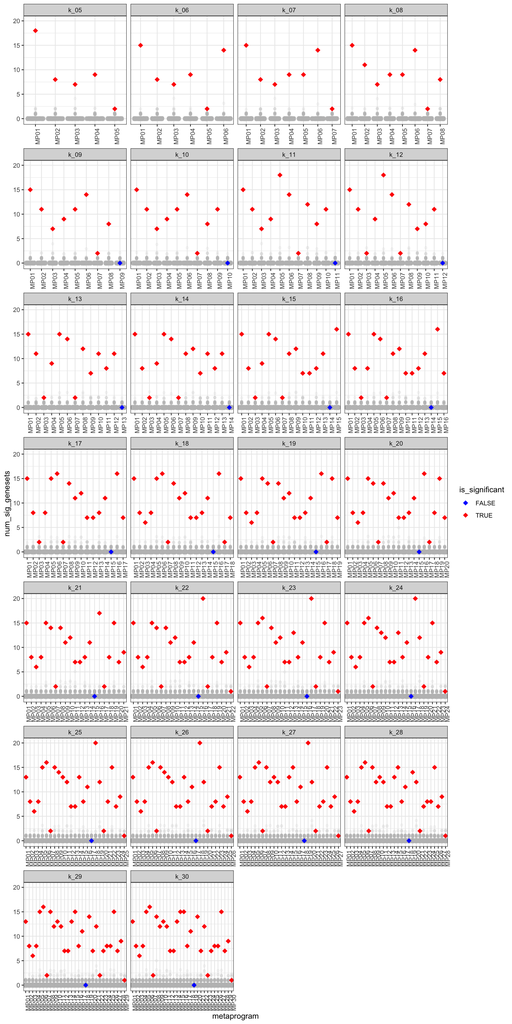

```r
# plot each metaprogram on the x axis with the number of observed gene sets on the y axis
# facet by k
plot_permutation_results(ora_background_df, ora_observed_df, metaprogram, num_sig_genesets) +
  facet_wrap(
    vars(n_metaprograms),
    scales = "free_x",
    ncol = 4
  )
```

Interestingly almost all metaprograms have a number of observed gene sets that are significant. It looks like at most each value of k has one metaprogram that’s not significant. I think this might be because that metaprogram has 0 gene sets?

```r
ora_observed_df |>
  dplyr::filter(!is_significant) |>
  dplyr::select(n_metaprograms, metaprogram, num_sig_genesets)
```

| n_metaprograms | metaprogram | num_sig_genesets |
| --- | --- | --- |
| k_09 | MP09 | 0 |
| k_10 | MP10 | 0 |
| k_11 | MP11 | 0 |
| k_12 | MP12 | 0 |
| k_13 | MP13 | 0 |
| k_14 | MP14 | 0 |
| k_15 | MP14 | 0 |
| k_16 | MP14 | 0 |
| k_17 | MP15 | 0 |
| k_18 | MP15 | 0 |

[output cut: 12 more lines]

As expected, it looks like the only time this number is not significant is if there are 0 gene sets identified. In this case we should probably just count how many metaprograms return 0 gene sets and not bother with the permutation testing.

## Uniquely mapped gene sets

Next we look at the total number of uniquely mapped gene sets across all metaprograms for a single value of k. For this, we shuffled the gene sets assigned to each metaprogram, keeping the total number of genesets per metaprogram consistent with observed values. We then re-calculated the total number of uniquely mapped gene sets. (Note that we also looked at proportion, but results are identical so I am only showing number here).

```r
# get the observed values from mp metrics
unique_geneset_obs_df <- mp_metrics_df |>
  dplyr::select(n_metaprograms, num_unique_genesets, unique_genesets_pvalue) |>
  dplyr::distinct() |>
  dplyr::mutate(
    is_significant = unique_genesets_pvalue <= sig_value
  )

# background distribution
unique_geneset_background_df <- mp_metrics_list |>
  purrr::map("unique_geneset_background_df") |>
  dplyr::bind_rows(.id = "n_metaprograms")
```

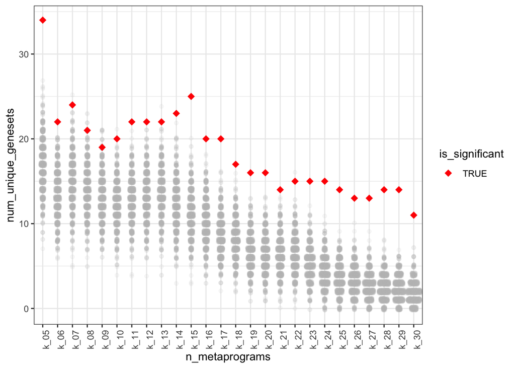

```r
plot_permutation_results(unique_geneset_background_df, unique_geneset_obs_df, n_metaprograms, num_unique_genesets)
```

Interestingly we see that every single value of k is significant for this metric. We also see that the total number of unique gene sets tends to decrease as you increase k. This makes some intuitive sense because as you increase k you are probably getting metaprograms that are less biologically distinct and differences may be more nuanced. Its likely that there will be multiple smaller metaprograms with the same gene set when you get to higher values of k.

I wonder if this metric is not the best because it seems dependent on k? I also wonder if we increase the gene set pool to include more specific gene sets other than hallmark, if this looks differenct.

Let’s re-run ORA but with both Hallmarks and a large gene set list. I’ll use the Reactome pathways for now. I tried with using KEGG and GO:Biological Process and the results are the same. As part of this we also will remove the EwS specific gene sets which I expect to be specific to multiple metaprograms especially as we increase k.

```r
# grab hallmarks and reactome
hallmarks_msigdb_df <- msigdbr::msigdbr(species = "Homo sapiens", collection = "H") |>
  dplyr::select(gs_name, ensembl_gene)
reactome_msigdb_df <- msigdbr::msigdbr(species = "Homo sapiens", collection = "C2", subcollection = "CP:REACTOME") |>
  dplyr::select(gs_name, ensembl_gene)

# create a single term2genedf for running ORA
all_term_df <- hallmarks_msigdb_df |>
  dplyr::bind_rows(reactome_msigdb_df) |>
  tidyr::drop_na()

# re-run ORA for each value of k
updated_ora_results_list <- metaprogram_files |>
  purrr::map(\(file){
    mp_object <- readr::read_rds(file)
    mp_object$metaprogram_list

    # get list of top genes for each mp
    top_genes <- extract_top_genes(mp_list = mp_object$metaprogram_list)

    # get ora results
    ora_results_df <- run_ora(
      mp_top_list = top_genes,
      gene_universe = mp_object$gene_universe,
      term2gene_df = all_term_df
    )

  })
```

```r
nreps <- 1000

# now re-do the permutation testing for number of uniquely mapped gene sets
updated_unique_geneset_results_df <- updated_ora_results_list |>
  purrr::map(\(results) {

    geneset_groups <- split(results$ID, results$metaprogram)

    obs_df <- prop_unique_mapped_genesets(geneset_groups) |>
      as.data.frame() |>
      dplyr::mutate(
        type = "observed",
        greater_than_obs = NA
      )

    obs_value <- unique(obs_df$num_unique_genesets)

    background_df <- permute_unique_genesets(results, nreps) |>
      dplyr::mutate(
        type = "background",
        # indicate which rows have background >= obs
        greater_than_obs = num_unique_genesets >= obs_value
      )

    # get a single pvalue
    pvalue <- (sum(background_df$greater_than_obs) +1)/(nreps + 1)


    # Combined data frame with obs and background together
    combined_df <- dplyr::bind_rows(obs_df, background_df) |>
      dplyr::mutate(unique_genesets_pvalue = pvalue,
                    is_significant = pvalue <= sig_value)

    return(combined_df)

  }) |>
  dplyr::bind_rows(.id = "n_metaprograms")
```

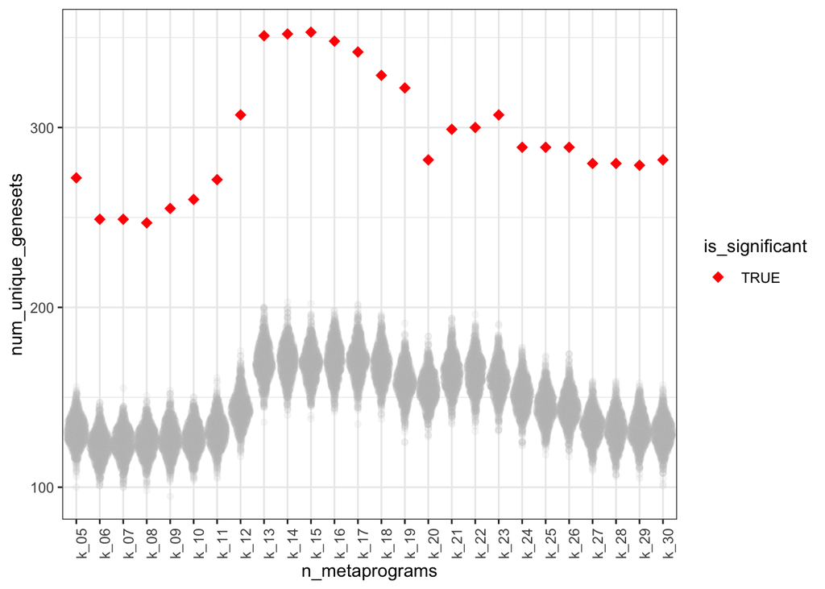

```r
updated_unique_geneset_background_df <- updated_unique_geneset_results_df |>
  dplyr::filter(type == "background")

updated_unique_geneset_obs_df <- updated_unique_geneset_results_df |>
  dplyr::filter(type == "observed")

plot_permutation_results(updated_unique_geneset_background_df, updated_unique_geneset_obs_df, n_metaprograms, num_unique_genesets)
```

Again, everything is significant. The one difference here is that the number of unique gene sets does not seem to be proportional to the value of k, so perhaps we could just use the number without permutation testing?

## Gene set specificity

What we’re really trying to measure is how much specificity there is in the gene sets that are observed. In other words, when a gene set is assigned, is it assigned to a single metaprogram or is it assigned across multiple metaprograms?

Here, I try to measure that by defining a metric that is 0 for gene sets that are spread across metaprograms and 1 for gene sets that are specific to metaprograms.

1 - (number of metaprograms the gene set is significant in - 1)/(total number of metaprograms - 1)

We can calculate this number for each gene set and then take the mean of all gene sets to get a single value of specificity for a metaprogram. I’ll also look at the overall mean of all metaprograms for a single value of k to get a single metric.

The one caveat here is that if a metaprogram has no gene sets assigned, then this value cannot be computed. We will look at the results using two different approaches - leaving the values as NA and not counting them towards the mean or converting the NA to 0 prior to computing the mean.

```r
# helper function for computing metaprogram specificity
compute_metaprogram_specificity <- function(ora_results_df, n_metaprograms) {

  # since not all metaprograms have gene sets, make sure we track all of them
  mp_names <- sprintf("MP%02d", seq(1, n_metaprograms))

  # calculate specificity for each gene set
  # one row per gene set
  geneset_specificity_df <- ora_results_df |>
    dplyr::group_by(ID) |>
    dplyr::summarize(num_mps = dplyr::n_distinct(metaprogram)) |>
    dplyr::mutate(geneset_specificity = 1 - (num_mps - 1) / (n_metaprograms - 1))

  # add gene set specificity to metaprograms
  # get one row per metaprogram with mean gene set specificity
  data.frame(metaprogram = mp_names) |>
    dplyr::left_join(ora_results_df, by = "metaprogram") |>
    dplyr::left_join(geneset_specificity_df, by = "ID") |>
    dplyr::summarize(mean_geneset_specificity = mean(geneset_specificity), .by = "metaprogram") |>
    dplyr::mutate(
      # add a new column to hep distinguish results considering 0s vs those with NA
      # applies to metaprograms with 0 gene sets returned
      mean_geneset_specificity_with_zeros = dplyr::if_else(is.na(mean_geneset_specificity), 0, mean_geneset_specificity)
    )
}
```

```r
specificity_df <- mp_metrics_list |>
  purrr::map(\(k){

    compute_metaprogram_specificity(k$ora_results_df, k$n_metaprograms)

  }) |>
  dplyr::bind_rows(.id = "n_metaprograms")
```

First let’s just look to see if the distribution of this metric for each value of k.

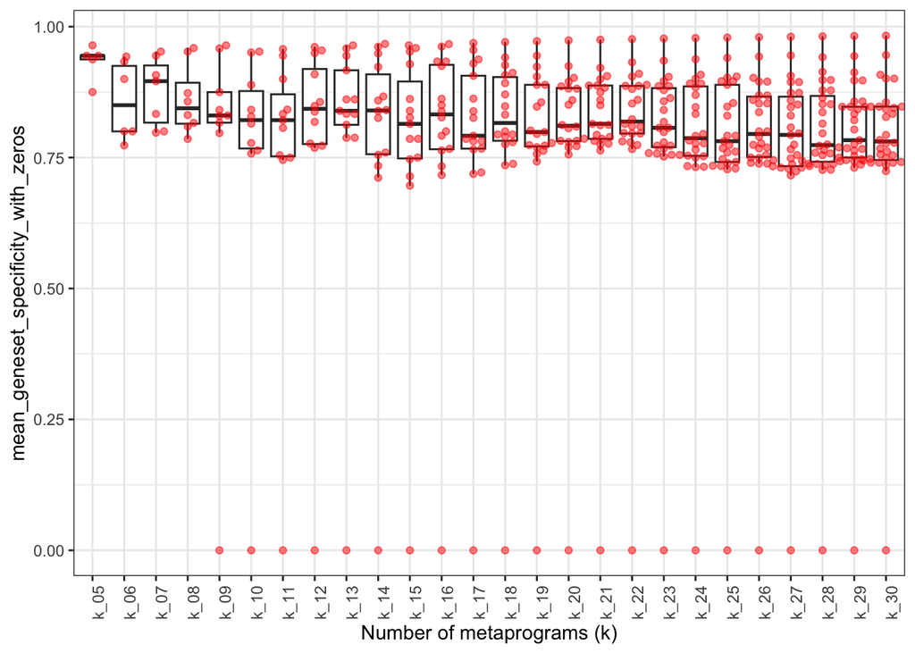

```r
ggplot(specificity_df, aes(x = n_metaprograms, y = mean_geneset_specificity_with_zeros)) +
  geom_boxplot(outlier.shape = NA) +
  ggbeeswarm::geom_beeswarm(color = "red", alpha = 0.5) +
  labs(
    x = "Number of metaprograms (k)"
  ) +
  theme(
    axis.text.x = element_text(angle = 90)
  )
```

Generally, this value is between 0.75 and 1 indicating high specificity. As you get to values of k with metaprograms with no gene sets, you see each value of k has 1 metaprogram with no gene sets.

If we just take the overall mean for each metaprogram, what are the top values of k?

```r
# rank by overall mean
obs_specificity_df <- specificity_df |>
  dplyr::summarize(
    overall_geneset_specificity = mean(mean_geneset_specificity, na.rm = TRUE),
    overall_geneset_specificity_with_zeros = mean(mean_geneset_specificity_with_zeros),
    .by = n_metaprograms
  )

obs_specificity_df |>
  dplyr::arrange(desc(overall_geneset_specificity)) |>
  DT::datatable()
```

|  | n_metaprograms | overall_geneset_specificity | overall_geneset_specificity_with_zeros |
| --- | --- | --- | --- |
| 1 | k_05 | 0.9331349206349207 | 0.9331349206349207 |
| 2 | k_07 | 0.8758597883597884 | 0.8758597883597884 |
| 3 | k_13 | 0.8666801948051949 | 0.8000124875124875 |
| 4 | k_09 | 0.8639965503246754 | 0.7679969336219337 |
| 5 | k_08 | 0.8605571016285303 | 0.8605571016285303 |
| 6 | k_12 | 0.8593401547947003 | 0.7877284752284752 |
| 7 | k_06 | 0.8582539682539683 | 0.8582539682539683 |
| 8 | k_14 | 0.8455486820871436 | 0.7851523476523476 |
| 9 | k_16 | 0.8446127946127946 | 0.791824494949495 |
| 10 | k_22 | 0.8440696240015968 | 0.8057028229106151 |

[output cut: 16 more lines]

If we sort by overall mean without zeros, then we see a mix of k values near the top.

By taking the overall mean with zeros, we are going to be penalizing values of k with a metaprogram with no gene sets. The top values of k all have all metaprograms with gene sets and the rest are ranked by the specificity of the remaining gene sets.

Let’s see if we can use permutation testing to define whether or not this gene set specificity is higher than what might be seen by random chance. To do this, we’ll shuffle the gene sets assigned to each metaprogram keeping the number of gene sets consistent with the observed values and then re-calculate specificity. We will also weight the gene sets by the number of times they are observed.

```r
permute_specificity <- function(
    ora_results_df,
    n_metaprograms,
    nreps
){

  # get gene set weights
  geneset_weights <- table(ora_results_df$ID)
  # pool of all significant gene sets across all metaprograms
  all_genesets <- names(geneset_weights)


  # get the size (number of sig gene sets) for each metaprogram
  mp_geneset_counts <- ora_results_df |>
    dplyr::group_by(metaprogram) |>
    dplyr::summarise(geneset_count = dplyr::n_distinct(ID), .groups = "drop")

  # shuffle genesets assigned to each metaprogram
  background <- replicate(
    nreps,
    {
      # keep the total number of genesets the same
      shuffled_ora_results <- mp_geneset_counts$geneset_count |>
        purrr::set_names(mp_geneset_counts$metaprogram) |>
        purrr::map(\(count){
          # sample without replacement from the full pool
          # ensuring no duplicate gene sets within a metaprogram
          sample(all_genesets, count, replace = FALSE, prob = geneset_weights)
        }) |>
        tibble::enframe(name = "metaprogram", value = "ID") |>
        tidyr::unnest_longer(ID)

      # number of MPs each gene set is observed in
      geneset_prop_df <- shuffled_ora_results |>
        dplyr::group_by(ID) |>
        dplyr::summarize(
          # get the num mps and proportion that each gene set is significant in
          num_mps = dplyr::n_distinct(metaprogram)
        ) |>
        dplyr::mutate(
          geneset_specificity = 1-(num_mps - 1)/(n_metaprograms - 1)
        )

      mp_geneset_counts |>
        dplyr::left_join(shuffled_ora_results, by = c("metaprogram")) |>
        dplyr::left_join(geneset_prop_df, by = c("ID")) |>
        dplyr::summarize(
          mean_geneset_specificity = mean(geneset_specificity),
          .by = "metaprogram"
        ) |>
        # make sure NA's are 0 since no gene sets occur
        dplyr::mutate(
          mean_geneset_specificity_with_zeros = dplyr::if_else(is.na(mean_geneset_specificity),0, mean_geneset_specificity),
          # get the overall mean across all MPs
          overall_geneset_specificity = mean(mean_geneset_specificity, na.rm = TRUE),
          overall_geneset_specificity_with_zeros = mean(mean_geneset_specificity_with_zeros)
        )

    }, simplify = FALSE
  ) |>
    dplyr::bind_rows(.id = "replicate")

  return(background)
}

# helper function to compute the pvalues for overall specificity
# returns a dataframe with one row per observed value
# new columns contain the specifity pvalue adj and is_significant
compute_specificity_pvalue <- function(background_df, obs_df, stat_column, nreps) {

  # join observed values with background values
  background_df |>
    dplyr::left_join(
      dplyr::rename(obs_df, obs_value = {{ stat_column }}),
      by = c("n_metaprograms")
    ) |>
    # indicator column for if background >= observation
    dplyr::mutate(greater_than_obs = {{ stat_column }} >= obs_value,
                  less_than_obs = {{ stat_column }} <= obs_value) |>
    dplyr::summarize(
      overall_geneset_specificity = unique(obs_value),
      # we see values that are both higher and lower so use a two-tailed test
      p_greater = (sum(greater_than_obs) + 1) / (nreps + 1),
      p_lower = (sum(less_than_obs) + 1) / (nreps + 1),
      overall_geneset_specificity_pvalue = min(p_greater, p_lower) * 2,
      .by = c("n_metaprograms")
    ) |>
    # add in adjusted pvalue
    dplyr::mutate(
      overall_geneset_specificity_adj_pvalue = p.adjust(overall_geneset_specificity_pvalue, method = "BH"),
      is_significant = overall_geneset_specificity_pvalue <= sig_value
    )
}
```

```r
nreps <- 1000

specificity_background <- mp_metrics_list |>
  purrr::map(\(k){

    permute_specificity(k$ora_results_df, k$n_metaprograms, nreps)
  }) |>
  dplyr::bind_rows(.id = "n_metaprograms")
```

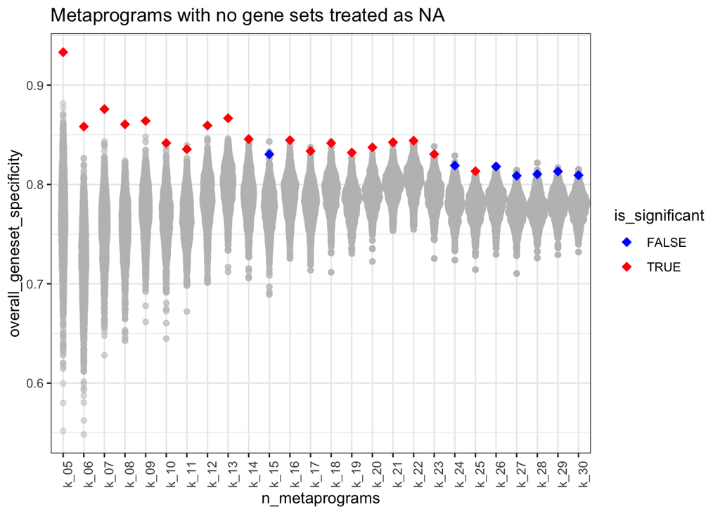

```r
specificity_pvalue_df <- compute_specificity_pvalue(specificity_background, obs_specificity_df, overall_geneset_specificity, nreps = nreps)

plot_permutation_results(specificity_background, specificity_pvalue_df, n_metaprograms, overall_geneset_specificity) +
  labs(
    title = "Metaprograms with no gene sets treated as NA"
  )
```

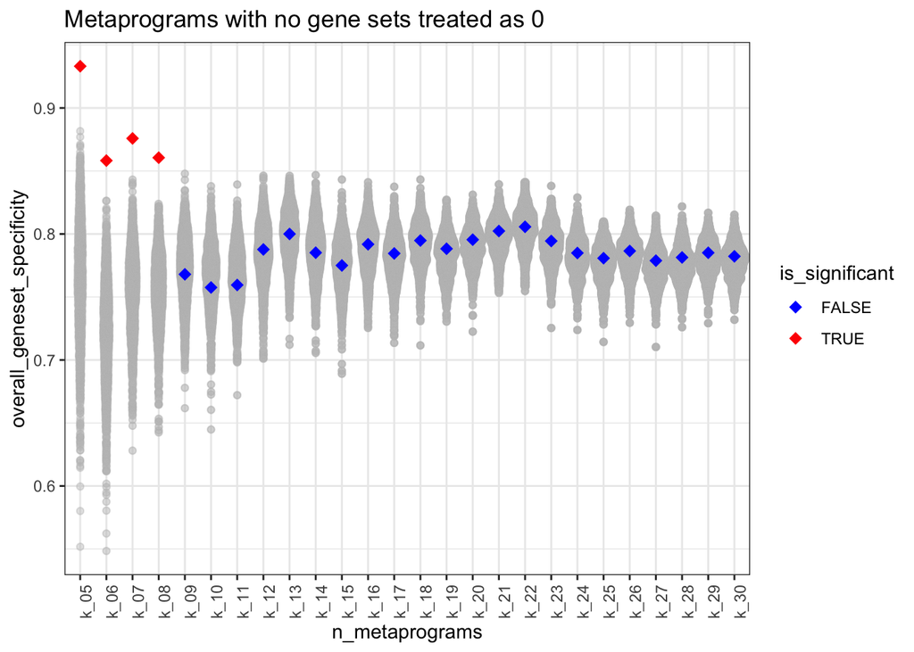

```r
specificity_pvalue_df <- compute_specificity_pvalue(specificity_background, obs_specificity_df, overall_geneset_specificity_with_zeros, nreps = nreps)

plot_permutation_results(specificity_background, specificity_pvalue_df, n_metaprograms, overall_geneset_specificity) +
  labs(
    title = "Metaprograms with no gene sets treated as 0"
  )
```

For both cases we see that the lower values of k are significant but more values of k are significant when we ignore metaprograms with 0 gene sets. If we include those metaprograms in the overall score, only k=5 through k=8 are significant which are the only values of k where all metaprograms have at least 1 significant gene set. This suggests that how we handle metaprograms with 0 gene sets can affect the interpretation of this score.

As a last evaluation, we’ll re-do this with different ORA results using the Reactome datasets we had looked at earlier.

```r
# updated the observed specificity and recalculate using new ora results
updated_specificity_df <- updated_ora_results_list |>
  purrr::imap(\(results, k){

    # first get all the MP names
    n_metaprograms <- stringr::str_remove(k, "k_") |>
      as.numeric()

    compute_metaprogram_specificity(results, n_metaprograms)

  }) |>
  dplyr::bind_rows(.id = "n_metaprograms")
```

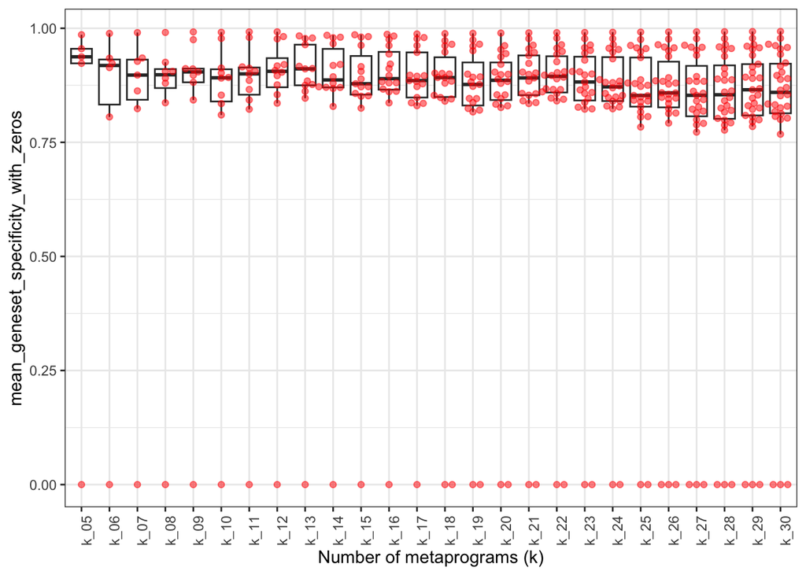

```r
ggplot(updated_specificity_df, aes(x = n_metaprograms, y = mean_geneset_specificity_with_zeros)) +
  geom_boxplot(outlier.shape = NA) +
  ggbeeswarm::geom_beeswarm(color = "red", alpha = 0.5) +
  labs(
    x = "Number of metaprograms (k)"
  ) +
  theme(
    axis.text.x = element_text(angle = 90)
  )
```

It looks like for this case we have metaprograms without gene sets across the board.

```r
# first get the observed df with overall mean for each metaprogram
updated_obs_specificity_df <- specificity_df |>
  dplyr::summarize(
    overall_geneset_specificity = mean(mean_geneset_specificity, na.rm = TRUE),
    overall_geneset_specificity_with_zeros = mean(mean_geneset_specificity_with_zeros),
    .by = n_metaprograms
  )

# recalculate background
updated_specificity_background <- updated_ora_results_list |>
  purrr::imap(\(results, k){
    n_metaprograms <- stringr::str_remove(k, "k_") |>
      as.numeric()
    permute_specificity(results, n_metaprograms, nreps)
  }) |>
  dplyr::bind_rows(.id = "n_metaprograms")
```

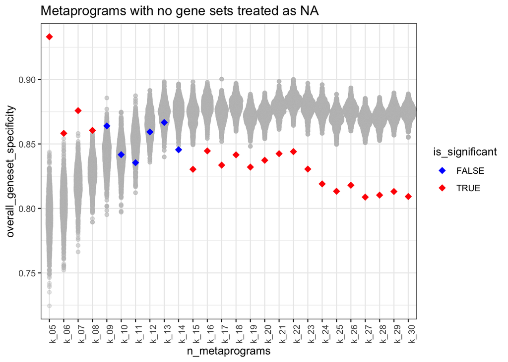

```r
# update pvalue
updated_specificity_pvalue_df <- compute_specificity_pvalue(updated_specificity_background, updated_obs_specificity_df, overall_geneset_specificity, nreps = nreps)

plot_permutation_results(updated_specificity_background, updated_specificity_pvalue_df, n_metaprograms, overall_geneset_specificity) +
  labs(
    title = "Metaprograms with no gene sets treated as NA"
  )
```

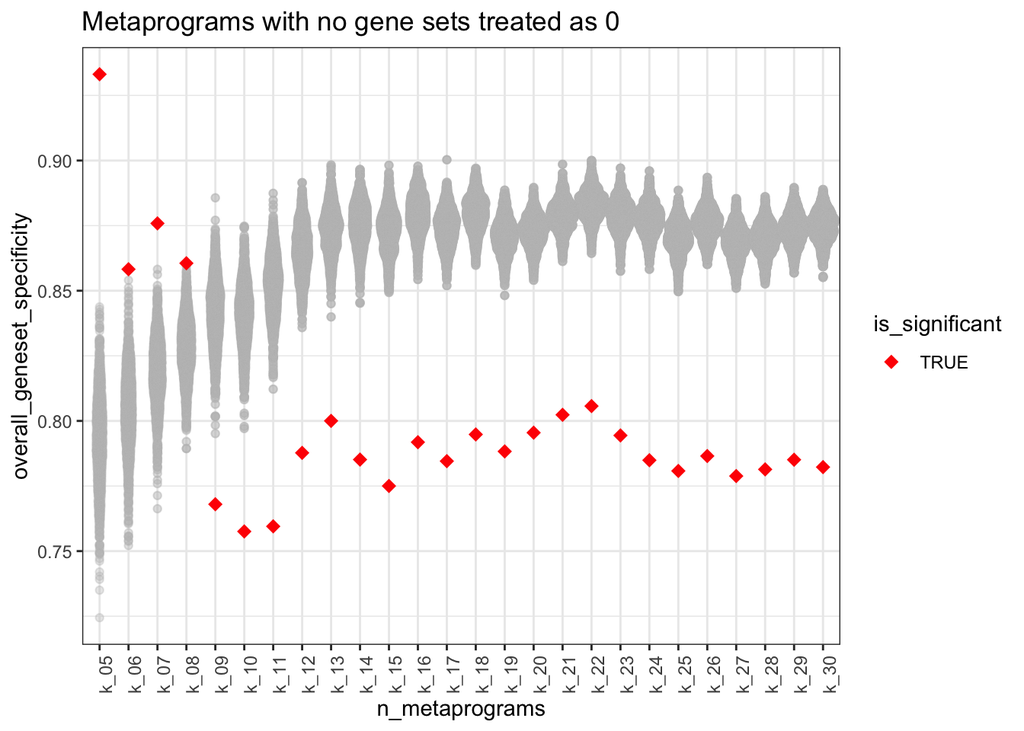

```r
# update pvalue
updated_specificity_pvalue_df <- compute_specificity_pvalue(updated_specificity_background, updated_obs_specificity_df, overall_geneset_specificity_with_zeros, nreps = nreps)

plot_permutation_results(updated_specificity_background, updated_specificity_pvalue_df, n_metaprograms, overall_geneset_specificity) +
  labs(
    title = "Metaprograms with no gene sets treated as 0"
  )
```

I think this might be something to consider moving forward as a metric and is probably our best option, but I’m still worried that for all these metrics the results are going to be somewhat dependent on k and dependent on the gene sets used for ORA.